# Lab 6 Simulation

Luisa Simpao

March 3, 2019

```r
library(tidyverse)
```

# Normal Approximation to the Binomial

1. Generate 1000 Samples from a binomial distribution with 20 trials & a 90% probability of success.

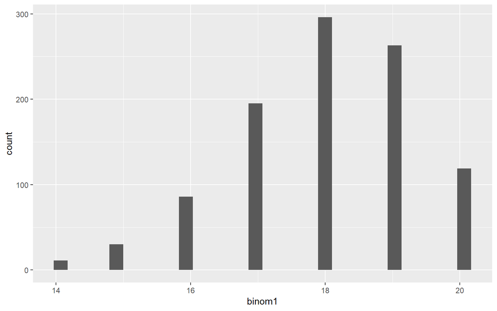

```r
my_samples <- data.frame(
  binom1 = rbinom(1000, size = 20, prob = 0.90)
)

#a Histogram
ggplot(my_samples, aes(x = binom1)) + geom_histogram()
```

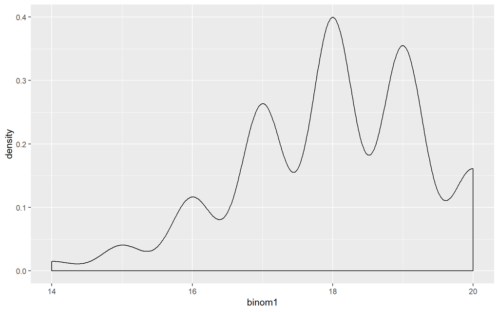

```r
#b Density plot
ggplot(my_samples, aes(x = binom1)) + geom_density()
```

2. Generate 1000 samples each from a binomial distribution with (a) 90%, (b) 70%, and (c) 50% chance of success.

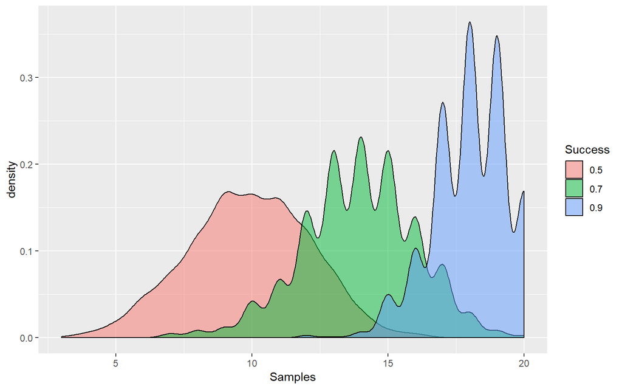

```r
success = c(0.90, 0.70, 0.50)

my_samples2 <- map_dfc(success, ~rbinom(1000, size = 20, prob = .x))

# Plot densities on top of each other
names(my_samples2) <- success
my_samples2 <- my_samples2 %>%
  gather(key = "Success", value = "Samples")

ggplot(my_samples2, aes(x = Samples, fill = Success)) +
  geom_density(alpha = 0.5)
```

3. Generate 1000 samples each from a binomial distribution with (a) 20, (b) 50, (c) 100 trials & a 90% chance of success

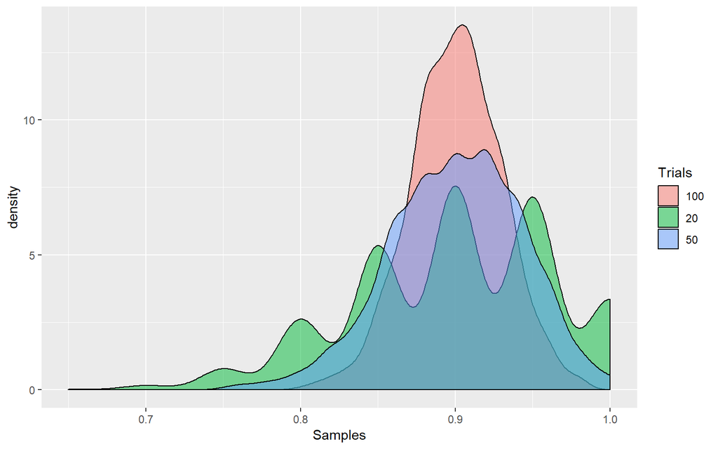

```r
trials = c(20, 50, 100)

my_samples3 <- map_dfc(trials, ~rbinom(1000, size = .x, prob = 0.90))

names(my_samples3) <- trials

my_samples3 <- my_samples3 %>%
  gather(key = "Trials", value = "Samples")

my_samples3 <- my_samples3 %>%
  mutate(Samples = as.numeric(Samples)/as.numeric(Trials))

ggplot(my_samples3, aes(x = Samples, fill = Trials)) +
  geom_density(alpha = 0.5)
```

4. Make a function that takes trials (vector) and prob_success and plots densities of sample proportions for every value of trials supplied.

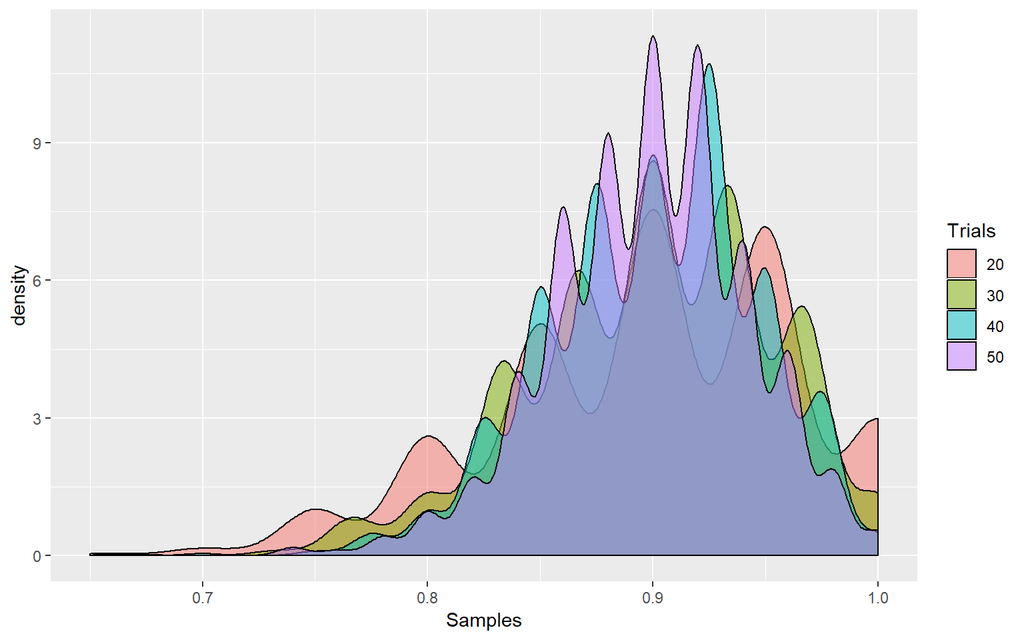

```r
plot_prop <- function(trials, prob_success){

  my_samplesN <- map_dfc(trials, ~rbinom(1000, size = .x, prob = prob_success))

  names(my_samplesN) <- trials

  my_samplesN <- my_samplesN %>%
    gather(key = "Trials", value = "Samples")

  my_samplesN <- my_samplesN %>%
    mutate(Samples = as.numeric(Samples)/as.numeric(Trials))

  ggplot(my_samplesN, aes(x = Samples, fill = Trials)) +
    geom_density(alpha = 0.5)
}

plot_prop(c(20,30,40,50), 0.9)
```

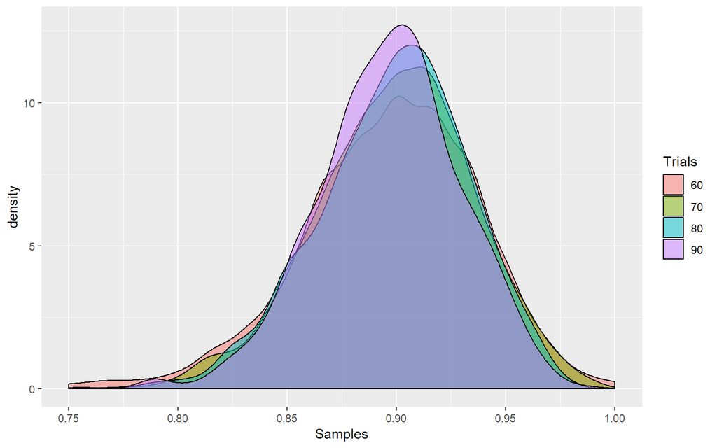

```r
plot_prop(c(60,70,80,90), 0.9)
```

5. There must be approximately more than 50 trials for normal approximation to be suitable for binomial data. Normality becomes more apparent as the number of trials increases.

# The Central Limit Theorem

1. (see below)

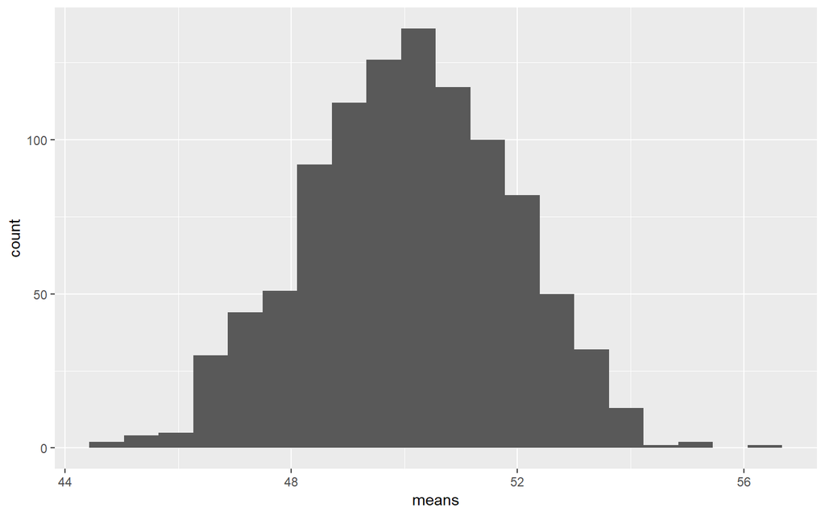

```r
# a 1000 samples of size 30
my_samples4 <- replicate(1000, rnorm(30, mean = 50, sd = 10), simplify = FALSE)

# my range function
range <- function(x){
  max(x) - min(x)
}

# 3rd quartile function
quart <- function(x){
quantile(x, probs = 0.75)
}

my_stats <- data.frame(
  means = map_dbl(my_samples4, mean),
  medians = map_dbl(my_samples4, median),
  sdevs = map_dbl(my_samples4, sd),
  ranges = map_dbl(my_samples4, range),
  quarts = map_dbl(my_samples4,quart)
)

# b Sampling distribution of means
ggplot(my_stats, aes(x = means)) + geom_histogram(bins = 20)
```

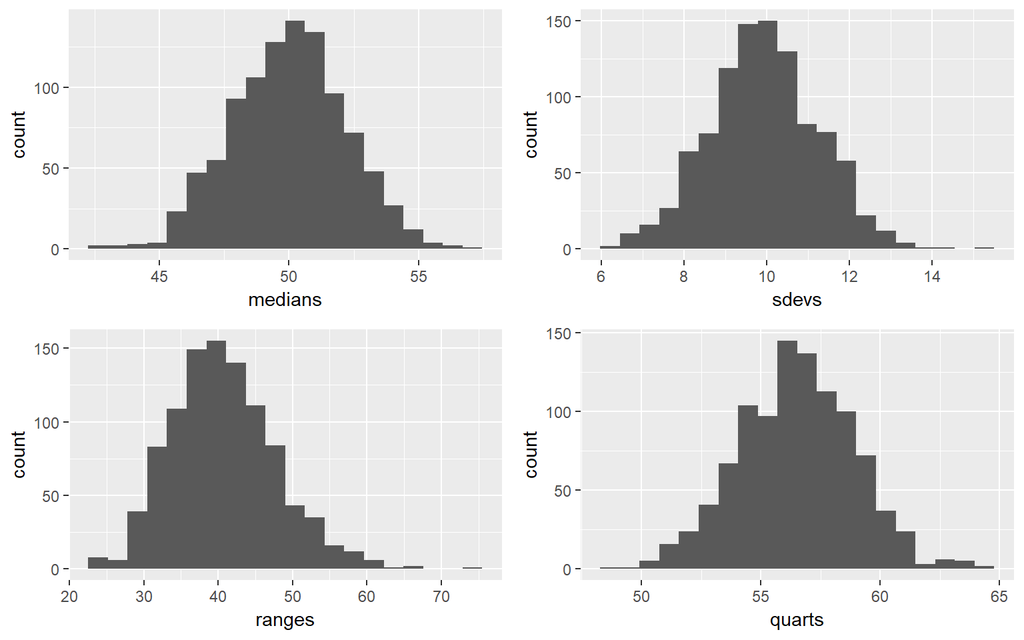

```r
# c Sampling distributions of other statistics in single plotting window
library(ggpubr)
m <- ggplot(my_stats, aes(x = medians)) + geom_histogram(bins = 20)
s <- ggplot(my_stats, aes(x = sdevs)) + geom_histogram(bins = 20)
r <- ggplot(my_stats, aes(x = ranges)) + geom_histogram(bins = 20)
q <- ggplot(my_stats, aes(x = quarts)) + geom_histogram(bins = 20)

ggarrange(m, s, r, q,
          ncol = 2, nrow = 2)
```

2. (see below)

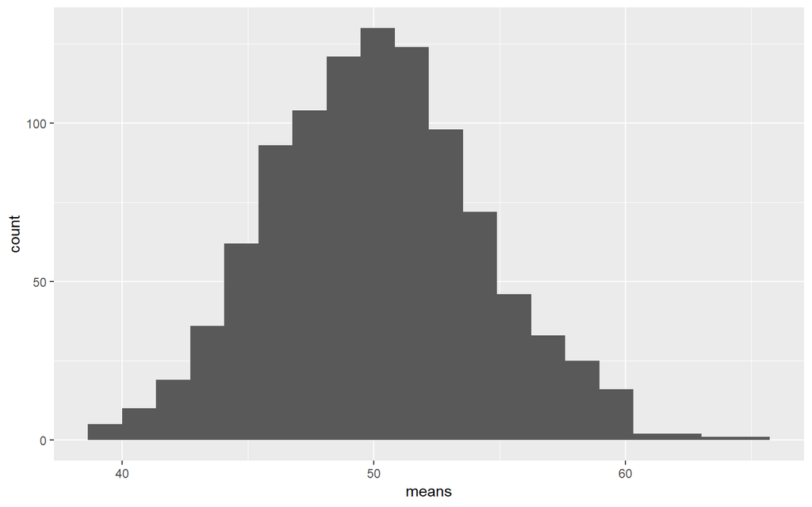

```r
# a
my_samples5 <- replicate(1000, runif(30, min = 10, max = 90), simplify = FALSE)

my_stats2 <- data.frame(
  means = map_dbl(my_samples5, mean),
  medians = map_dbl(my_samples5, median),
  sdevs = map_dbl(my_samples5, sd),
  ranges = map_dbl(my_samples5, range),
  quarts = map_dbl(my_samples5,quart)
)

# b
ggplot(my_stats2, aes(x = means)) + geom_histogram(bins = 20)
```

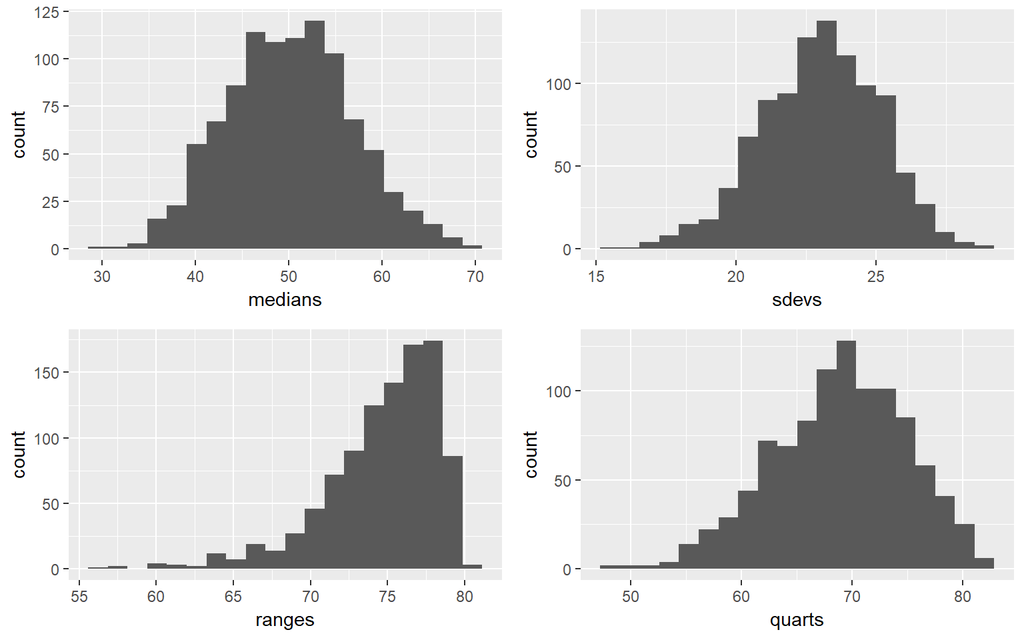

```r
# c
m <- ggplot(my_stats2, aes(x = medians)) + geom_histogram(bins = 20)
s <- ggplot(my_stats2, aes(x = sdevs)) + geom_histogram(bins = 20)
r <- ggplot(my_stats2, aes(x = ranges)) + geom_histogram(bins = 20)
q <- ggplot(my_stats2, aes(x = quarts)) + geom_histogram(bins = 20)

ggarrange(m, s, r, q,
          ncol = 2, nrow = 2)
```

3. Based on the graphs generated, the Central Limit seems to apply to other statistics, including median, standard deviation, range, and the 3rd quartile, for both Normal and Uniform Distributions. For the Normal distribution, ranges are slighly skewed right, but appears mostly normal. However, for the Uniform distribution, ranges are highly skewed left and the 3rd quartiles is slightly skewed left.